# DS 220 - Project #2 on Data Analysis with Python

## by. Jin Won

Dataset of interest: Crime Data from 2020 to 2024

from: https://catalog.data.gov/dataset/crime-data-from-2020-to-present?from_hint=eyJzb3J0IjoicG9wdWxhcml0eSJ9

```python
!pip install numpy
!pip install matplotlib
!pip install pandas
import numpy as np
import matplotlib.pyplot as plt
import pandas as pd
```

```python
crime_data = pd.read_csv("crime_data.csv")
crime_data
```

|  | DR_NO | Date Rptd | DATE OCC | TIME OCC | AREA | AREA NAME | Rpt Dist No | Part 1-2 | Crm Cd | Crm Cd Desc | ... | Status | Status Desc | Crm Cd 1 | Crm Cd 2 | Crm Cd 3 | Crm Cd 4 | LOCATION | Cross Street | LAT | LON |
| --- | --- | --- | --- | --- | --- | --- | --- | --- | --- | --- | --- | --- | --- | --- | --- | --- | --- | --- | --- | --- | --- |
| 0 | 211507896 | 04/11/2021 12:00:00 AM | 11/07/2020 12:00:00 AM | 845 | 15 | N Hollywood | 1502 | 2 | 354 | THEFT OF IDENTITY | ... | IC | Invest Cont | 354.0 | NaN | NaN | NaN | 7800 BEEMAN AV | NaN | 34.2124 | -118.4092 |
| 1 | 201516622 | 10/21/2020 12:00:00 AM | 10/18/2020 12:00:00 AM | 1845 | 15 | N Hollywood | 1521 | 1 | 230 | ASSAULT WITH DEADLY WEAPON, AGGRAVATED ASSAULT | ... | IC | Invest Cont | 230.0 | NaN | NaN | NaN | ATOLL AV | N GAULT | 34.1993 | -118.4203 |
| 2 | 240913563 | 12/10/2024 12:00:00 AM | 10/30/2020 12:00:00 AM | 1240 | 9 | Van Nuys | 933 | 2 | 354 | THEFT OF IDENTITY | ... | IC | Invest Cont | 354.0 | NaN | NaN | NaN | 14600 SYLVAN ST | NaN | 34.1847 | -118.4509 |
| 3 | 210704711 | 12/24/2020 12:00:00 AM | 12/24/2020 12:00:00 AM | 1310 | 7 | Wilshire | 782 | 1 | 331 | THEFT FROM MOTOR VEHICLE - GRAND ($950.01 AND ... | ... | IC | Invest Cont | 331.0 | NaN | NaN | NaN | 6000 COMEY AV | NaN | 34.0339 | -118.3747 |
| 4 | 201418201 | 10/03/2020 12:00:00 AM | 09/29/2020 12:00:00 AM | 1830 | 14 | Pacific | 1454 | 1 | 420 | THEFT FROM MOTOR VEHICLE - PETTY ($950 & UNDER) | ... | IC | Invest Cont | 420.0 | NaN | NaN | NaN | 4700 LA VILLA MARINA | NaN | 33.9813 | -118.4350 |
| ... | ... | ... | ... | ... | ... | ... | ... | ... | ... | ... | ... | ... | ... | ... | ... | ... | ... | ... | ... | ... | ... |
| 1004889 | 240710284 | 07/24/2024 12:00:00 AM | 07/23/2024 12:00:00 AM | 1400 | 7 | Wilshire | 788 | 1 | 510 | VEHICLE - STOLEN | ... | IC | Invest Cont | 510.0 | NaN | NaN | NaN | 4000 W 23RD ST | NaN | 34.0362 | -118.3284 |
| 1004890 | 240104953 | 01/15/2024 12:00:00 AM | 01/15/2024 12:00:00 AM | 100 | 1 | Central | 101 | 2 | 745 | VANDALISM - MISDEAMEANOR ($399 OR UNDER) | ... | IC | Invest Cont | 745.0 | NaN | NaN | NaN | 1300 W SUNSET BL | NaN | 34.0685 | -118.2460 |
| 1004891 | 240410786 | 10/14/2024 12:00:00 AM | 10/11/2024 12:00:00 AM | 2330 | 4 | Hollenbeck | 421 | 1 | 341 | THEFT-GRAND ($950.01 & OVER)EXCPT,GUNS,FOWL,LI... | ... | IC | Invest Cont | 341.0 | NaN | NaN | NaN | 1700 ALBION ST | NaN | 34.0675 | -118.2240 |
| 1004892 | 240309674 | 04/24/2024 12:00:00 AM | 04/24/2024 12:00:00 AM | 1500 | 3 | Southwest | 358 | 1 | 230 | ASSAULT WITH DEADLY WEAPON, AGGRAVATED ASSAULT | ... | IC | Invest Cont | 230.0 | NaN | NaN | NaN | FLOWER ST | JEFFERSON BL | 34.0215 | -118.2868 |
| 1004893 | 240910892 | 08/13/2024 12:00:00 AM | 08/12/2024 12:00:00 AM | 2300 | 9 | Van Nuys | 914 | 1 | 510 | VEHICLE - STOLEN | ... | IC | Invest Cont | 510.0 | NaN | NaN | NaN | 6900 VESPER AV | NaN | 34.1961 | -118.4510 |

1004894 rows × 28 columns

# Questions to answer for analysis:

- How do the crime rates differ by area? What are the top 10 areas that have the highest crime rates?
- What is the trend of the crime rate overtime in each area?
- What is the overall trend of the crime rate overtime? Was it higher during pandemic or post-pandemic?
- What is the most common crime type? Why may this be the case?
- What can we conclude about this dataset and the crimes during/after the pandemic?

# Comparing crime rates by area

## Question:

What are the top 10 areas that have the highest crime rates?

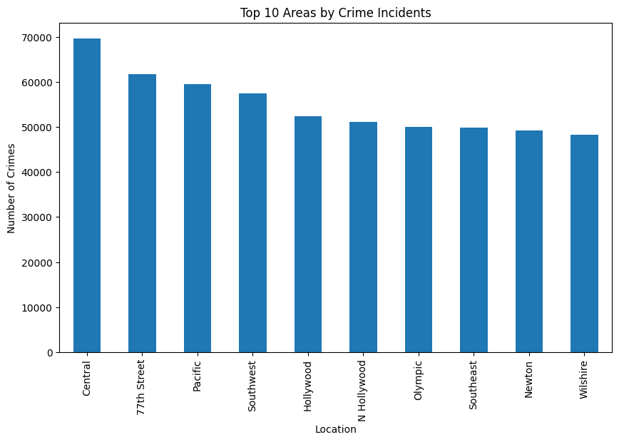

```python
area_count = crime_data["AREA NAME"].value_counts()
top_ten = area_count.head(10)

fig, ax = plt.subplots(figsize=(10,6))
top_ten.plot(kind="bar")

plt.title("Top 10 Areas by Crime Incidents")
plt.xlabel("Location")
plt.ylabel("Number of Crimes")

plt.show()
```